# Object Detection with YOLOv8 - Regularization

```python
from google.colab import drive
drive.mount('/content/drive')
```

Regularization is defensive (we attempt to stop overfitting), while Hyperparameter tuning is offensive (we try to push performance higher).

1. Learning rate scheduler adjusts the learning rate in real time during training to enhance convergence and prevent overfitting in later stages. Prevents the "spikes" we saw in our validation loss curve in Notebook 02.
2. Batch size management: using the largest possible batch size that fits GPU memory improves batch normalization statistics, which aids in regularization. Affects training speed and noise in the gradient updates. (`batch=-1`)

```python
from google.colab import drive
drive.mount('/content/drive/')

# Shared drive
# %cd '/content/drive/MyDrive/minichallenge_hs25_object_detection'
# %cd '/content/drive/MyDrive/FHNW/MC'

# # Original drive
%cd '/content/drive/MyDrive/FHNW/HS_25/DLBS/minichallenge_hs25_object_detection/MC'

from helpers import (
    load_roboflow_data,
    save_weights_to_drive,
    visualize_training_results,
    display_yolo_plots,
    diagnose_training_results
)
```

```
/content/drive/.shortcut-targets-by-id/1DgLXJnKkWgH1Se3L7wSkYBuXljrUEqpi/MC
```

```python
!ls -F 'Santa-10'
DATASET_PATH = 'Santa-10'
```

```
data.yaml  README.dataset.txt  README.roboflow.txt  test/  train/  valid/
```

```python
!nvidia-smi
```

```
Mon Jan 12 10:55:48 2026
+-----------------------------------------------------------------------------------------+
| NVIDIA-SMI 550.54.15              Driver Version: 550.54.15      CUDA Version: 12.4     |
|-----------------------------------------+------------------------+----------------------+
| GPU  Name                 Persistence-M | Bus-Id          Disp.A | Volatile Uncorr. ECC |
| Fan  Temp   Perf          Pwr:Usage/Cap |           Memory-Usage | GPU-Util  Compute M. |
|                                         |                        |               MIG M. |
|=========================================+========================+======================|
|   0  NVIDIA A100-SXM4-40GB          Off |   00000000:00:04.0 Off |                    0 |
| N/A   29C    P0             45W /  400W |       5MiB /  40960MiB |      0%      Default |
|                                         |                        |             Disabled |
+-----------------------------------------+------------------------+----------------------+

+-----------------------------------------------------------------------------------------+
| Processes:                                                                              |
|  GPU   GI   CI        PID   Type   Process name                              GPU Memory |
|        ID   ID                                                               Usage      |
|=========================================================================================|
|  No running processes found                                                             |
+-----------------------------------------------------------------------------------------+
```

Install Dependencies & Authentication (Ultralitycs and Weights & Biases)

```python
# Install YOLO library
!pip install ultralytics -q

from IPython import display
display.clear_output()

# prevent ultralytics from tracking activity
!yolo settings sync=False

import ultralytics
ultralytics.checks()

from ultralytics import YOLO
```

```
Ultralytics 8.3.252 🚀 Python-3.12.12 torch-2.9.0+cu126 CUDA:0 (NVIDIA A100-SXM4-40GB, 40507MiB)
Setup complete ✅ (12 CPUs, 83.5 GB RAM, 38.5/112.6 GB disk)
```

# Best model from before, YOLO s

```python
# Load best YOLOv8 model (from before)
model = YOLO('yolov8_results/best_regularize_2.pt')
```

## Tuning strategy

YOLO's tune() method vs "manual" Grid search

1. The model.tune() method automates the search for the best hyperparameters (like learning rate, momentum, and augmentation scales). It uses a **Genetic Algorithm** to evolve parameters over many generations.

Mimicking natural selection, it starts by running a small batch of training trials (e.g., 10 trials) using completely random hyperparameter values within a defined range. It evaluates the performance of each trial based on a fitness metric, typically Validation mAP50-95.

It selects the best-performing trials ("parents") and creates the next generation of trials ("offspring") by making small, random tweaks (mutations) to the successful parents' hyperparameters.

It explores the hyperparameter space much more efficiently than grid or random search, converging on near-optimal values much faster.

2. **Grid Search** (testing every combination) is computationally expensive, but in our case, when the model already performs well and we want to tweak specific performance issues it might be better.

Since our model already hits ~0.90 mAP, but suffers from a "precision cliff" at high recall, we should tune for Regularization (Weight Decay and Label Smoothing) rather than just "more learning". A focused grid search on weight_decay and box gain is the next step.

```python
fine_tuning_config = {
    'data': 'Santa_vs_Grinch.yaml',  # Path to dataset.yaml
    'epochs': 50,  # Fine-tuning for fewer epochs, as you’re starting from a pre-trained model
    'imgsz': 512,
    'batch': 16,
    'lr0': 0.0001,  # Lower learning rate for fine-tuning
    'lrf': 0.01,
    'momentum': 0.937,
    'weight_decay': 0.0005,
    'optimizer': 'AdamW',
    'save': True,
    'project': 'runs/fine_tune_santa_grinch',
    'name': 'santa_vs_grinch',
    'verbose': True,
    'patience': 10,  # Early stopping patience
}

# Start training with the updated configuration
model.train(**fine_tuning_config)
```

[output not shown]

The configuration below addresses the precision cliff and localization errors observed in our previous runs.

1. `label_smoothing=0.1` prevents the model from being 100% certain about its labels, which stops it from becoming "overconfident" and crashing at high recall—directly smoothing that PR curve cliff.
2. `box=bg` & `close_mosaic=20` Testing box gains forces the model to prioritize bounding box precision, which is the specific medicine for our high DFL loss. Disabling Mosaic for the final 20 epochs allows the model to "clean up" bounding boxes on standard, non-distorted images to lower our DFL loss.
3. `weight_decay=wd` & `patience=15`: These tackle the loss ratio by penalizing complex weights (preventing memorization) and stopping the training before the model overfits. Optimal L2 value is being searched for.
4. `warmup_epochs=10` & `lrf=0.01`: A longer warmup prevents early gradient instability on your small dataset, while a lower final learning rate ensures the model settles gently into its "best" weights.

The inclusion of label_smoothing=0.1 and lrf=0.01 in every run ensures that regardless of which wd or bg wins, the model is protected against the "overconfidence cliff" at high recall.

With `cos_lr=True` and extended `warmup_epochs=10`, the first 10% of our training will be very slow and stable, which prevents the model from overfitting to our small dataset early on.

After the grid search finishes, we don't just pick the run with the highest mAP50. We need to compare the Confusion Matrices—the best run is the one that manages to keep False Negatives (missed Santas) low while also reducing those False Positives (hallucinated Santas).

```python
import os
import pandas as pd

tune_dir = 'runs/detect/runs/tune'
os.makedirs(tune_dir, exist_ok=True)
print(f"Directory ready at: {tune_dir}")
```

```
Directory ready at: runs/detect/runs/tune
```

```python
# DEFINE GRID PARAMETERS
# Targeting the 1.55 loss ratio and DFL/Box inaccuracies
weight_decays = [0.001, 0.002]
box_gains = [10.0, 12.0]

# EXECUTE GRID SEARCH
for wd in weight_decays:
    for bg in box_gains:
      model = YOLO('yolov8_results/best_regularize_2.pt')

      run_name = f"final_tune_wd{wd}_box{bg}"
      print(f"\n🚀 Starting Run: {run_name}")

      model.train(
          data='Santa-10/data.yaml',
          project=tune_dir,       # Directs all runs into your new folder
          name=run_name,
          epochs=150,
          imgsz=640,
          weight_decay=wd,        # Fixes the 1.55 loss gap (overfitting)
          box=bg,                 # Addresses high DFL/box loss
          label_smoothing=0.1,    # Prevents "precision cliff" overconfidence
          lrf=0.01,               # Stabilizes end-of-training results
          warmup_epochs=10,       # Slows early learning for small datasets
          close_mosaic=20,        # Refines box edges in the final 20 epochs
          patience=15,            # Safety net for the late-stage mAP drop
          optimizer='AdamW',
          momentum=0.937,         # AdamW beta1 for gradient stability
          cos_lr=True             # Smoother learning rate decay
      )
```

[output not shown]

[output cut: 2900 more lines]

```
                   all        155        105      0.749      0.655      0.752       0.48
EarlyStopping: Training stopped early as no improvement observed in last 15 epochs. Best results observed at epoch 92, best model saved as best.pt.
To update EarlyStopping(patience=15) pass a new patience value, i.e. `patience=300` or use `patience=0` to disable EarlyStopping.

107 epochs completed in 0.165 hours.
Optimizer stripped from /content/drive/.shortcut-targets-by-id/1DgLXJnKkWgH1Se3L7wSkYBuXljrUEqpi/MC/runs/detect/runs/detect/runs/tune/final_tune_wd0.002_box12.0/weights/last.pt, 22.5MB
Optimizer stripped from /content/drive/.shortcut-targets-by-id/1DgLXJnKkWgH1Se3L7wSkYBuXljrUEqpi/MC/runs/detect/runs/detect/runs/tune/final_tune_wd0.002_box12.0/weights/best.pt, 22.5MB

Validating /content/drive/.shortcut-targets-by-id/1DgLXJnKkWgH1Se3L7wSkYBuXljrUEqpi/MC/runs/detect/runs/detect/runs/tune/final_tune_wd0.002_box12.0/weights/best.pt...
Ultralytics 8.3.252 🚀 Python-3.12.12 torch-2.9.0+cu126 CUDA:0 (NVIDIA A100-SXM4-40GB, 40507MiB)
Model summary (fused): 72 layers, 11,125,971 parameters, 0 gradients, 28.4 GFLOPs
                 Class     Images  Instances      Box(P          R      mAP50  mAP50-95): 100% ━━━━━━━━━━━━ 5/5 3.9it/s 1.3s
                   all        155        105      0.686       0.81      0.768      0.487
Speed: 0.1ms preprocess, 1.9ms inference, 0.0ms loss, 1.5ms postprocess per image
Results saved to /content/drive/.shortcut-targets-by-id/1DgLXJnKkWgH1Se3L7wSkYBuXljrUEqpi/MC/runs/detect/runs/detect/runs/tune/final_tune_wd0.002_box12.0
```

```python
%pwd
```

```
'/content/drive/.shortcut-targets-by-id/1DgLXJnKkWgH1Se3L7wSkYBuXljrUEqpi/MC'
```

```python
# ANALYZE RESULTS
tune_dir = '/content/drive/.shortcut-targets-by-id/1DgLXJnKkWgH1Se3L7wSkYBuXljrUEqpi/MC/runs/detect/runs/detect/runs/tune/'
def find_best_run(base_dir=tune_dir):
    all_results = []

    # Check if directory exists and has contents
    if not os.path.exists(base_dir) or not os.listdir(base_dir):
        return print("\n❌ No training results found in the directory.")

    for run_folder in os.listdir(base_dir):
        # Path to the specific results CSV generated by YOLO
        csv_path = os.path.join(base_dir, run_folder, 'results.csv')

        if os.path.exists(csv_path):
            df = pd.read_csv(csv_path)
            df.columns = df.columns.str.strip() # Remove whitespace from YOLO headers

            # Extract peak performance metrics
            best_map50 = df['metrics/mAP50(B)'].max()
            best_recall = df['metrics/recall(B)'].max()

            all_results.append({
                'Run Name': run_folder,
                'mAP50': best_map50,
                'Recall': best_recall
            })

    if not all_results:
        return print("\n❌ No 'results.csv' files were found.")

    # Create summary table and rank by mAP
    results_df = pd.DataFrame(all_results).sort_values(by='mAP50', ascending=False)


    print("GRID SEARCH RANKINGS:")
    print(results_df.to_string(index=False))

    top_run = results_df.iloc[0]['Run Name']
    print(f"\n✨ WINNER: {top_run}")
    print(f"Path to best weights: {os.path.join(base_dir, top_run, 'weights', 'best.pt')}")

# Run the analysis
find_best_run()
```

```
GRID SEARCH RANKINGS:
                   Run Name   mAP50  Recall
 final_tune_wd0.002_box10.0 0.84402 0.83810
final_tune_wd0.001_box10.03 0.83938 0.81905
final_tune_wd0.001_box10.04 0.83675 0.85594
final_tune_wd0.001_box10.05 0.83675 0.85594
 final_tune_wd0.001_box12.0 0.80138 0.79048
 final_tune_wd0.002_box12.0 0.76795 0.81365

✨ WINNER: final_tune_wd0.002_box10.0
Path to best weights: /content/drive/.shortcut-targets-by-id/1DgLXJnKkWgH1Se3L7wSkYBuXljrUEqpi/MC/runs/detect/runs/detect/runs/tune/final_tune_wd0.002_box10.0/weights/best.pt
```

```python
%pwd
```

```
'/content/drive/.shortcut-targets-by-id/1DgLXJnKkWgH1Se3L7wSkYBuXljrUEqpi/MC'
```

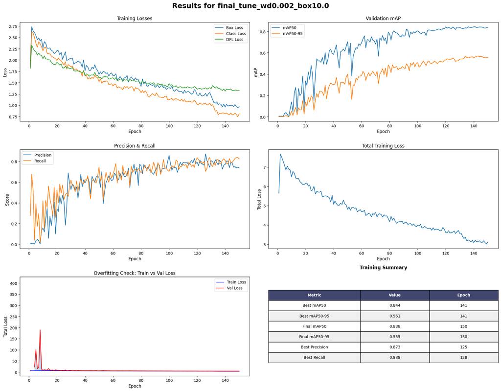

[output not shown]

```python
import pandas as pd
import matplotlib.pyplot as plt

RUNS_DIR = './runs/detect/runs/detect/runs/tune/final_tune_wd0.002_box10.0'

# Run 1
visualize_training_results(RUNS_DIR)
```

```python
diagnose_training_results(RUNS_DIR)
```

```
================================================================================
🔍 TRAINING DIAGNOSTICS
================================================================================

📈 FINAL METRICS (Epoch 150):
   mAP50:     0.8379
   mAP50-95:  0.5554
   Precision: 0.7364
   Recall:    0.8249

🎯 BEST METRICS (Epoch 141):
   mAP50:     0.8440
   mAP50-95:  0.5606
   Precision: 0.8049
   Recall:    0.7810

📉 LOSS VALUES:
   Final Box Loss:   0.9667
   Final Class Loss: 0.8124
   Final DFL Loss:   1.3280

⚠️  POTENTIAL ISSUES:
   ✅ No obvious issues detected!

================================================================================
```

|  | epoch | time | train/box_loss | train/cls_loss | train/dfl_loss | metrics/precision(B) | metrics/recall(B) | metrics/mAP50(B) | metrics/mAP50-95(B) | val/box_loss | val/cls_loss | val/dfl_loss | lr/pg0 | lr/pg1 | lr/pg2 |
| --- | --- | --- | --- | --- | --- | --- | --- | --- | --- | --- | --- | --- | --- | --- | --- |
| 0 | 1 | 7.2510 | 1.98251 | 1.84780 | 1.81636 | 0.00901 | 0.27619 | 0.00570 | 0.00114 | 5.21466 | 387.52900 | 14.83960 | 0.091204 | 0.000977 | 0.000977 |
| 1 | 2 | 13.4340 | 2.73743 | 2.61019 | 2.32825 | 0.00613 | 0.67619 | 0.00477 | 0.00127 | 4.28826 | inf | 37.70410 | 0.082204 | 0.001977 | 0.001977 |
| 2 | 3 | 19.2031 | 2.64307 | 2.60556 | 2.25712 | 0.00797 | 0.52381 | 0.00594 | 0.00159 | 4.44723 | inf | 53.85920 | 0.073203 | 0.002976 | 0.002976 |
| 3 | 4 | 25.0675 | 2.60857 | 2.49581 | 2.20504 | 0.00054 | 0.03810 | 0.00082 | 0.00016 | 6.57208 | 4.27201 | 11.57300 | 0.064201 | 0.003973 | 0.003973 |
| 4 | 5 | 30.6457 | 2.53768 | 2.37195 | 2.18180 | 0.03283 | 0.39048 | 0.02924 | 0.00551 | 3.96065 | 92.07510 | 4.78886 | 0.055196 | 0.004969 | 0.004969 |
| ... | ... | ... | ... | ... | ... | ... | ... | ... | ... | ... | ... | ... | ... | ... | ... |
| 145 | 146 | 804.7390 | 0.97113 | 0.79012 | 1.32581 | 0.74591 | 0.81081 | 0.84050 | 0.56469 | 1.51558 | 0.95482 | 1.64612 | 0.000127 | 0.000127 | 0.000127 |
| 146 | 147 | 810.1080 | 1.01549 | 0.82600 | 1.33408 | 0.75086 | 0.82857 | 0.83397 | 0.55419 | 1.51608 | 0.97453 | 1.65117 | 0.000117 | 0.000117 | 0.000117 |
| 147 | 148 | 816.6020 | 0.96799 | 0.79178 | 1.33391 | 0.73769 | 0.83810 | 0.83058 | 0.55346 | 1.51913 | 0.98065 | 1.64798 | 0.000110 | 0.000110 | 0.000110 |
| 148 | 149 | 822.3250 | 0.94764 | 0.74551 | 1.31813 | 0.74595 | 0.83810 | 0.83408 | 0.55392 | 1.51704 | 0.97076 | 1.64328 | 0.000104 | 0.000104 | 0.000104 |
| 149 | 150 | 827.4750 | 0.96675 | 0.81239 | 1.32801 | 0.73643 | 0.82491 | 0.83789 | 0.55541 | 1.51927 | 0.96350 | 1.64760 | 0.000101 | 0.000101 | 0.000101 |

150 rows × 15 columns

Our previous run with 0.89 mAP was likely memorizing specific pixels of the Santa dataset. With 0.89 mAP the model was a specialist at identifying those exact training images. It had very high precision because it had memorized the background noise and specific lighting of your small dataset. Current model with 0.84 mAP is more 'honest'. By adding `weight_decay=0.002` and `label_smoothing=0.1`, we forced the model to be less sure of itself, but more likely to find a Santa in a totally new, unseen photo.

Box/Class Loss is now igher. Because of label_smoothing, we essentially told the model "even if you see a Santa, don't be 100% sure." This keeps the "Class Loss" slightly higher because the model never reaches a loss of zero. But DFL is lower because the model is much more "confident" about where the edges of the Santa are.

```python
%pwd
```

```
'/content/drive/.shortcut-targets-by-id/1DgLXJnKkWgH1Se3L7wSkYBuXljrUEqpi/MC'
```

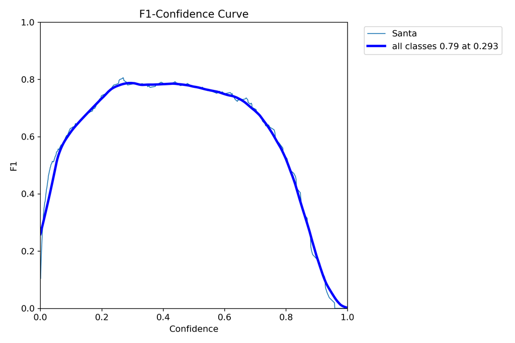

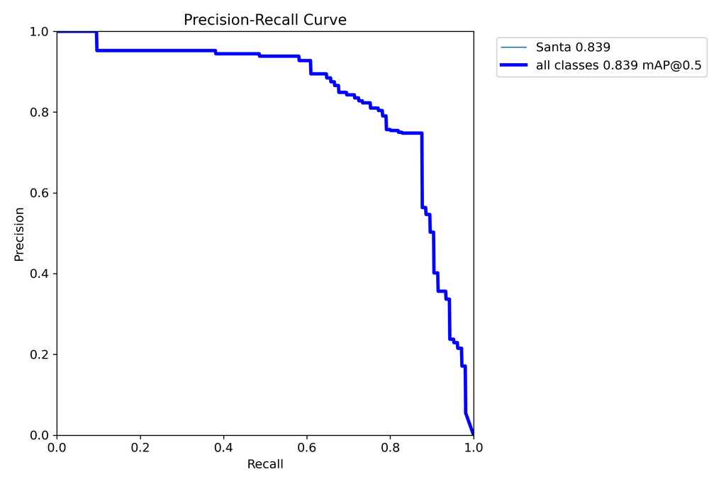

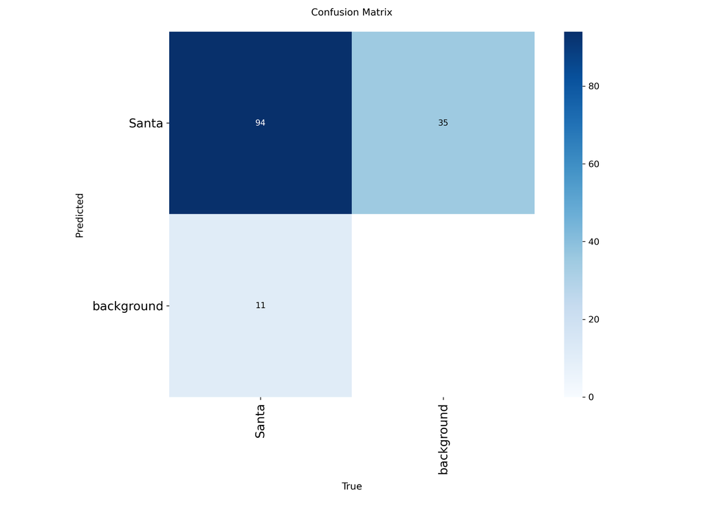

```python
import os
from IPython.display import Image, display
import matplotlib.pyplot as plt

# F1 curve
f1_path = os.path.join(RUNS_DIR, 'BoxF1_curve.png')
display(Image(filename=f1_path, width=600))

# Precision Recall  curve
pr_path = os.path.join(RUNS_DIR, 'BoxPR_curve.png')
display(Image(filename=pr_path, width=600))

# Confusion matrix
cm_path = os.path.join(RUNS_DIR, 'confusion_matrix.png')
display(Image(filename=cm_path, width=600))
```

By increasing the box gain to 10.0, we forced the model to prioritize tight bounding boxes. On our tiny dataset our manual annotations aren't pixel-perfect, so a high box gain actually penalizes the model for "finding" the Santa but being slightly off on the edges, which causes more false negatives.

The 35 False Positives suggest that while the model is more honest now, it hasn't learned to distinguish Santa from background textures yet optimally.

The current grid search showed that box=12.0 was too high, and weight_decay=0.002 might be too restrictive for such a small sample size.

We should lower box gain slightly back to 8.5 or 9.0 to reduce the False Negatives caused by over-punishing coordinates. Since your Class Loss is high and False Positives are at 35, we need to increase the weight of the classification task relative to the box task.

### Run on a test set

```python
# Run validation on the test split
MODEL_PATH = 'runs/detect/runs/detect/runs/tune/final_tune_wd0.002_box10.0/weights/best.pt'
model = YOLO(MODEL_PATH)
metrics = model.val(data='Santa-10/data.yaml', split='test')
print(f"Test results saved to: {metrics.save_dir}")

# Precision, recall, and mAP results
precision = metrics.results_dict['metrics/precision(B)']
recall = metrics.results_dict['metrics/recall(B)']
mAP50 = metrics.results_dict['metrics/mAP50(B)']
mAP50_95 = metrics.results_dict['metrics/mAP50-95(B)']

print(f"Precision: {precision:.2f}")
print(f"Recall: {recall:.2f}")
print(f"mAP50: {mAP50:.2f}")
print(f"mAP50-95: {mAP50_95:.2f}")
```

```
Ultralytics 8.3.252 🚀 Python-3.12.12 torch-2.9.0+cu126 CUDA:0 (NVIDIA A100-SXM4-40GB, 40507MiB)
Model summary (fused): 72 layers, 11,125,971 parameters, 0 gradients, 28.4 GFLOPs
val: Fast image access ✅ (ping: 0.5±0.1 ms, read: 0.1±0.0 MB/s, size: 34.2 KB)
val: Scanning /content/drive/.shortcut-targets-by-id/1DgLXJnKkWgH1Se3L7wSkYBuXljrUEqpi/MC/Santa-10/test/labels.cache... 95 images, 42 backgrounds, 0 corrupt: 100% ━━━━━━━━━━━━ 95/95 23.4Mit/s 0.0s
                 Class     Images  Instances      Box(P          R      mAP50  mAP50-95): 100% ━━━━━━━━━━━━ 6/6 1.4s/it 8.5s
                   all         95         53      0.927       0.83      0.924      0.686
Speed: 3.3ms preprocess, 3.5ms inference, 0.0ms loss, 2.7ms postprocess per image
Results saved to /content/drive/.shortcut-targets-by-id/1DgLXJnKkWgH1Se3L7wSkYBuXljrUEqpi/MC/runs/detect/val6
Test results saved to: /content/drive/.shortcut-targets-by-id/1DgLXJnKkWgH1Se3L7wSkYBuXljrUEqpi/MC/runs/detect/val6
Precision: 0.93
Recall: 0.83
mAP50: 0.92
mAP50-95: 0.69
```

```python
RUNS_DIR = 'runs/detect/val6'
```

```python
%pwd
```

```
'/content/drive/.shortcut-targets-by-id/1DgLXJnKkWgH1Se3L7wSkYBuXljrUEqpi/MC'
```

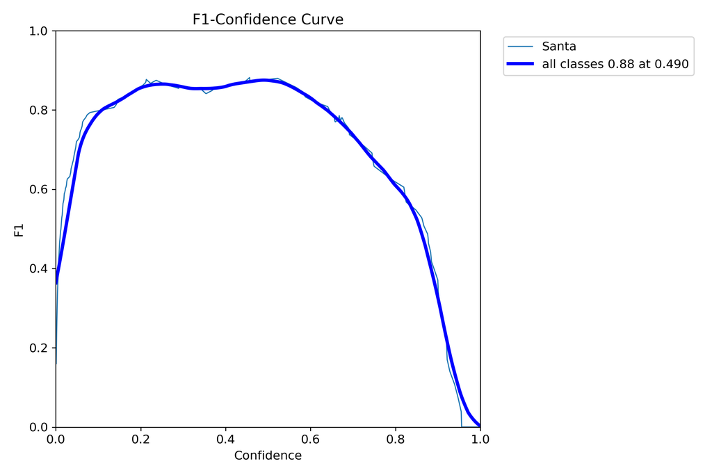

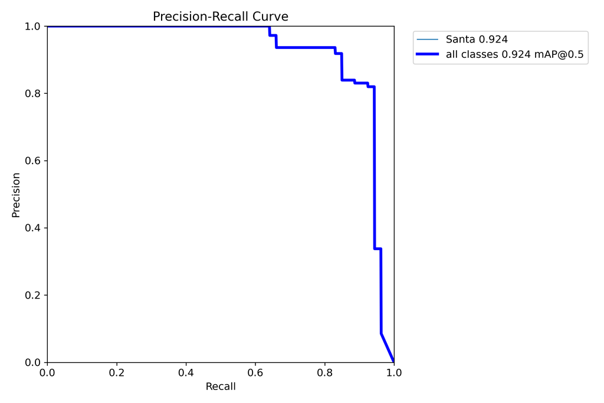

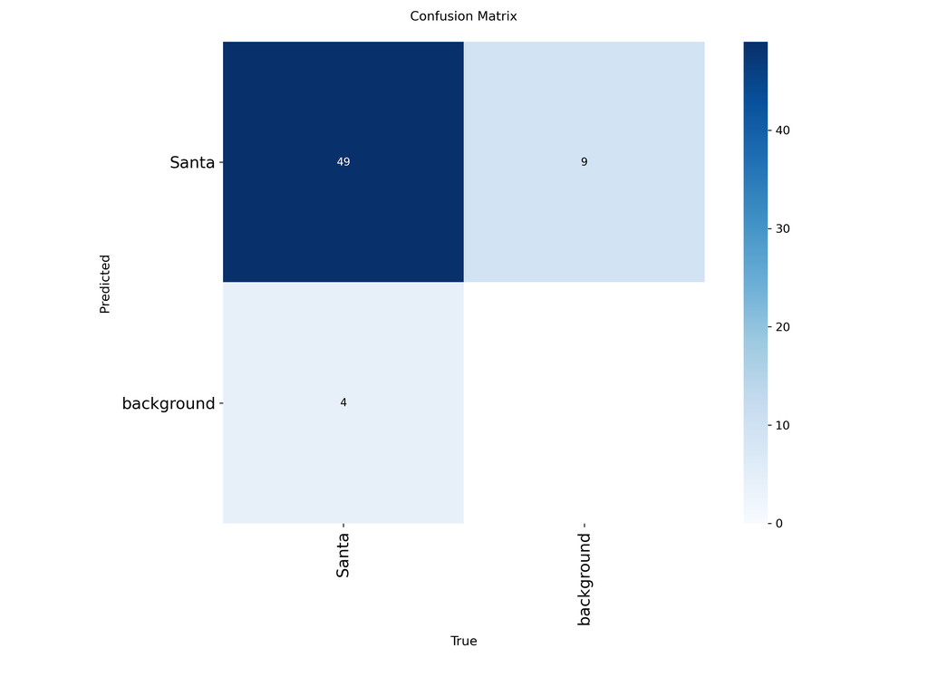

```python
# F1 curve
f1_path = os.path.join(RUNS_DIR, 'BoxF1_curve.png')
display(Image(filename=f1_path, width=600))

# Precision Recall  curve
pr_path = os.path.join(RUNS_DIR, 'BoxPR_curve.png')
display(Image(filename=pr_path, width=600))

# Confusion matrix
cm_path = os.path.join(RUNS_DIR, 'confusion_matrix.png')
display(Image(filename=cm_path, width=600))
```

The PR curve shows that, while the model still runs out of knowledge eventually, it is now accurately identifying a much larger percentage of Santas before it begins to fail.

With only only 9 FP is an improvement over previous runs where the model would "hallucinate" Santas in background textures. The model has become much more conservative and reliable, though at the cost of some sensitivity (Recall is down). But only 4 FN is also a great result.

```python
!jupyter nbconvert --to html '/content/drive/MyDrive/FHNW/HS_25/DLBS/minichallenge_hs25_object_detection/MC/04_model_tuning.ipynb'
```